# Portfolio Optimization Practice

Alex Kong

2/25/2021

# R session: Loading market data

loading some stock data from three different sectors: * sector technology: AAPL, AMD, ADI. * sector healthcare: ABBV, AEZS, A. * sector basic materials: APD, AA, CF.

```r
library(xts)  # to manipulate time series of stock data
library(quantmod)  # to download stock data
library(PerformanceAnalytics)  # to compute performance measures
library(CVXR)
#library(nloptr)

# download data from YahooFinance
#stock_namelist <- c("AMD", "ADI", "APD", "BA", "DD", "M", "JNPR", "INTC", "GS", "IBM", "NOK", "XOM", "WFC")

stock_namelist <- c("AAPL", "AMD", "ADI", "ABBV", "AEZS", "A", "APD", "AA", "CF")
prices <- xts()
for (i in 1:length(stock_namelist)) {
  tmp <- Ad(getSymbols(stock_namelist[i], from = "2013-01-01", to = "2016-12-31", auto.assign = FALSE))
  tmp <- na.approx(tmp, na.rm = FALSE)  # interpolate NAs
 # tmp <- na.approx(tmp, na.rm = TRUE)  # interpolate NAs
  prices <- cbind(prices, tmp)
}
```

[output not shown]

```r
colnames(prices) <- stock_namelist
tclass(prices) <- "Date"

head(prices)
```

```
##                AAPL  AMD      ADI     ABBV AEZS        A      APD       AA
## 2013-01-02 17.03979 2.53 36.03962 25.10313  253 27.76513 65.28445 20.62187
## 2013-01-03 16.82472 2.49 35.45807 24.89585  254 27.86458 65.05634 20.80537
## 2013-01-04 16.35606 2.59 34.82738 24.58134  257 28.41485 65.93076 21.24121
## 2013-01-07 16.25985 2.67 34.93387 24.63138  259 28.20932 65.86992 20.87419
## 2013-01-08 16.30361 2.67 34.57346 24.09529  255 27.98391 65.99159 20.87419
## 2013-01-09 16.04880 2.63 34.48337 24.23110  258 28.73970 66.88123 20.82831
##                  CF
## 2013-01-02 32.77139
## 2013-01-03 32.61643
## 2013-01-04 33.34700
## 2013-01-07 33.22208
## 2013-01-08 32.73503
## 2013-01-09 33.87990
```

```r
tail(prices)
```

```
##                AAPL   AMD      ADI     ABBV AEZS        A      APD    AA
## 2016-12-22 27.49304 11.60 67.33305 50.75754 4.10 44.27052 131.9025 29.75
## 2016-12-23 27.54741 11.58 67.69058 51.31730 4.10 44.49201 132.2547 29.71
## 2016-12-27 27.72236 12.07 68.12144 51.44902 4.05 44.79056 133.0673 29.65
## 2016-12-28 27.60415 11.55 67.43391 51.25968 3.55 44.02976 131.0267 29.43
## 2016-12-29 27.59706 11.59 67.45223 51.63835 3.60 44.07998 131.1266 28.89
## 2016-12-30 27.38192 11.34 66.57219 51.54779 3.60 44.00271 130.6271 28.08
##                  CF
## 2016-12-22 26.26244
## 2016-12-23 26.78576
## 2016-12-27 27.86731
## 2016-12-28 27.58820
## 2016-12-29 27.82370
## 2016-12-30 27.45737
```

```r
# compute log-returns and linear returns
X_log <- diff(log(prices))[-1]
X_lin <- (prices/lag(prices) - 1)[-1]
# or alternatively...
X_log <- CalculateReturns(prices, "log")[-1]
X_lin <- CalculateReturns(prices)[-1]

head(X_lin)
```

```
##                    AAPL          AMD          ADI         ABBV         AEZS
## 2013-01-03 -0.012621870 -0.015810277 -0.016136517 -0.008257336  0.003952569
## 2013-01-04 -0.027855034  0.040160643 -0.017786868 -0.012632949  0.011811024
## 2013-01-07 -0.005882284  0.030888031  0.003057680  0.002035487  0.007782101
## 2013-01-08  0.002691107  0.000000000 -0.010316978 -0.021764395 -0.015444015
## 2013-01-09 -0.015628933 -0.014981273 -0.002605698  0.005636496  0.011764706
## 2013-01-10  0.012396628 -0.003802281  0.012113781  0.002949680 -0.003875969
##                       A           APD           AA           CF
## 2013-01-03  0.003581795 -0.0034941090  0.008898612 -0.004728424
## 2013-01-04  0.019747866  0.0134408570  0.020948193  0.022398897
## 2013-01-07 -0.007232980 -0.0009227408 -0.017278772 -0.003746184
## 2013-01-08 -0.007990692  0.0018470647  0.000000000 -0.014660402
## 2013-01-09  0.027008163  0.0134811279 -0.002197690  0.034974005
## 2013-01-10  0.007381530 -0.0009095228 -0.012114520  0.015029353
```

```r
N <- ncol(X_log)  # number of stocks
T <- nrow(X_log)  # number of days
cat("N:", N, "T:", T, "\n")
```

```
## N: 9 T: 1007
```

Take a look at the share price

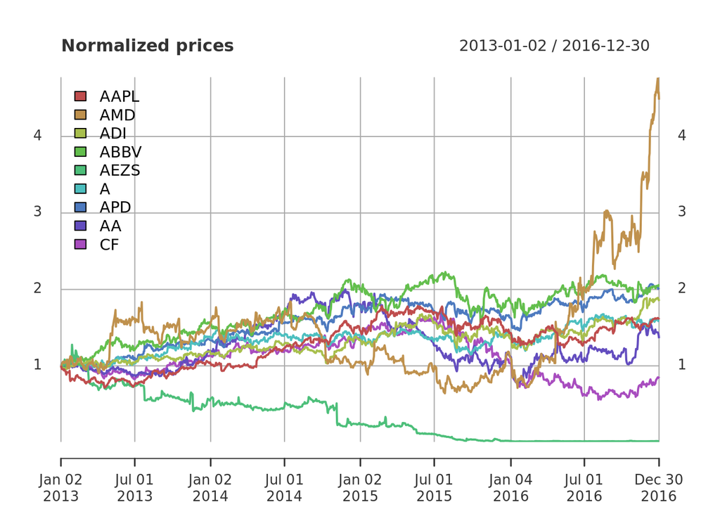

```r
plot(prices/rep(prices[1, ], each = nrow(prices)), col = rainbow10equal, legend.loc = "topleft",
     main = "Normalized prices")
```

Divide data into a training set and a test set

```r
T_trn <- round(0.7*T)  # 70% of data
X_log_trn <- X_log[1:T_trn, ]
X_log_tst <- X_log[(T_trn+1):T, ]
X_lin_trn <- X_lin[1:T_trn, ]
X_lin_tst <- X_lin[(T_trn+1):T, ]
```

Estimate mu and sigma with the training set

```r
#mu <- colMeans(X_log_trn)
mu <- colMeans(X_log_trn, na.rm = TRUE)
#Sigma <- cov(X_log_trn)
Sigma <- cov(X_log_trn)
mu
```

```
##          AAPL           AMD           ADI          ABBV          AEZS
##  0.0006102079 -0.0003193217  0.0005605781  0.0007783541 -0.0053072766
##             A           APD            AA            CF
##  0.0003123183  0.0007646484  0.0001062232  0.0003806217
```

```r
Sigma
```

```
##              AAPL          AMD          ADI         ABBV         AEZS
## AAPL 2.653788e-04 5.737769e-05 8.029478e-05 4.516970e-05 1.284881e-05
## AMD  5.737769e-05 9.737922e-04 1.350831e-04 7.139426e-05 8.155996e-05
## ADI  8.029478e-05 1.350831e-04 2.298377e-04 9.632609e-05 8.348316e-06
## ABBV 4.516970e-05 7.139426e-05 9.632609e-05 2.632279e-04 1.068497e-04
## AEZS 1.284881e-05 8.155996e-05 8.348316e-06 1.068497e-04 4.450190e-03
## A    5.848224e-05 1.105702e-04 1.030762e-04 9.400947e-05 2.918058e-05
## APD  5.488551e-05 8.120154e-05 7.866565e-05 7.195737e-05 1.091484e-05
## AA   7.519825e-05 1.124511e-04 1.057782e-04 7.502725e-05 1.198334e-04
## CF   5.512600e-05 7.459661e-05 8.089612e-05 6.652691e-05 2.168022e-05
##                 A          APD           AA           CF
## AAPL 5.848224e-05 5.488551e-05 7.519825e-05 5.512600e-05
## AMD  1.105702e-04 8.120154e-05 1.124511e-04 7.459661e-05
## ADI  1.030762e-04 7.866565e-05 1.057782e-04 8.089612e-05
## ABBV 9.400947e-05 7.195737e-05 7.502725e-05 6.652691e-05
## AEZS 2.918058e-05 1.091484e-05 1.198334e-04 2.168022e-05
## A    1.957970e-04 8.629229e-05 9.907265e-05 7.702853e-05
## APD  8.629229e-05 1.666708e-04 8.744715e-05 8.208825e-05
## AA   9.907265e-05 8.744715e-05 3.654074e-04 1.155405e-04
## CF   7.702853e-05 8.208825e-05 1.155405e-04 3.092940e-04
```

Buy & Hold Strategy

```r
# a B&H portfolio is trivially the zero vector with a one on the stock held
w_BnH <- diag(N)
rownames(w_BnH) <- colnames(X_lin)
colnames(w_BnH) <- paste0("B&H-", colnames(X_lin))
dim(w_BnH)
```

```
## [1] 9 9
```

```r
dim(X_lin)
```

```
## [1] 1007    9
```

```r
w_BnH
```

```
##      B&H-AAPL B&H-AMD B&H-ADI B&H-ABBV B&H-AEZS B&H-A B&H-APD B&H-AA B&H-CF
## AAPL        1       0       0        0        0     0       0      0      0
## AMD         0       1       0        0        0     0       0      0      0
## ADI         0       0       1        0        0     0       0      0      0
## ABBV        0       0       0        1        0     0       0      0      0
## AEZS        0       0       0        0        1     0       0      0      0
## A           0       0       0        0        0     1       0      0      0
## APD         0       0       0        0        0     0       1      0      0
## AA          0       0       0        0        0     0       0      1      0
## CF          0       0       0        0        0     0       0      0      1
```

```r
# compute returns of all B&H portfolios
ret_BnH <- xts(X_lin %*% w_BnH, index(X_lin))
ret_BnH_trn <- ret_BnH[1:T_trn, ]
ret_BnH_tst <- ret_BnH[-c(1:T_trn), ]
head(ret_BnH)
```

```
##                B&H-AAPL      B&H-AMD      B&H-ADI     B&H-ABBV     B&H-AEZS
## 2013-01-03 -0.012621870 -0.015810277 -0.016136517 -0.008257336  0.003952569
## 2013-01-04 -0.027855034  0.040160643 -0.017786868 -0.012632949  0.011811024
## 2013-01-07 -0.005882284  0.030888031  0.003057680  0.002035487  0.007782101
## 2013-01-08  0.002691107  0.000000000 -0.010316978 -0.021764395 -0.015444015
## 2013-01-09 -0.015628933 -0.014981273 -0.002605698  0.005636496  0.011764706
## 2013-01-10  0.012396628 -0.003802281  0.012113781  0.002949680 -0.003875969
##                   B&H-A       B&H-APD       B&H-AA       B&H-CF
## 2013-01-03  0.003581795 -0.0034941090  0.008898612 -0.004728424
## 2013-01-04  0.019747866  0.0134408570  0.020948193  0.022398897
## 2013-01-07 -0.007232980 -0.0009227408 -0.017278772 -0.003746184
## 2013-01-08 -0.007990692  0.0018470647  0.000000000 -0.014660402
## 2013-01-09  0.027008163  0.0134811279 -0.002197690  0.034974005
## 2013-01-10  0.007381530 -0.0009095228 -0.012114520  0.015029353
```

```r
tail(ret_BnH, n = 10)
```

```
##                 B&H-AAPL      B&H-AMD       B&H-ADI     B&H-ABBV    B&H-AEZS
## 2016-12-16  0.0012951978 -0.018416206 -0.0206490731  0.003224652 -0.02631579
## 2016-12-19  0.0057772108  0.027204503  0.0099874494  0.000000000  0.02702703
## 2016-12-20  0.0026578397  0.051141553  0.0081032564 -0.000964124  0.01315789
## 2016-12-21  0.0009404656 -0.003475239  0.0027247663 -0.011422217  0.02597403
## 2016-12-22 -0.0065776879  0.011333915 -0.0020384440  0.003417379  0.03797468
## 2016-12-23  0.0019777736 -0.001724138  0.0053099633  0.011028135  0.00000000
## 2016-12-27  0.0063509417  0.042314335  0.0063651839  0.002566737 -0.01219512
## 2016-12-28 -0.0042640665 -0.043082022 -0.0100927248 -0.003680129 -0.12345679
## 2016-12-29 -0.0002569179  0.003463203  0.0002716437  0.007387288  0.01408451
## 2016-12-30 -0.0077958664 -0.021570319 -0.0130469070 -0.001753755  0.00000000
##                   B&H-A       B&H-APD       B&H-AA       B&H-CF
## 2016-12-16 -0.013960639 -0.0111342526 -0.013091675  0.028970470
## 2016-12-19 -0.010455382  0.0019671797 -0.003741463 -0.040366563
## 2016-12-20  0.017169530 -0.0014894479  0.029702935  0.024743833
## 2016-12-21 -0.003678763 -0.0010167478  0.008952255 -0.003104421
## 2016-12-22 -0.001520459 -0.0085514008 -0.022346369  0.041868518
## 2016-12-23  0.005003172  0.0026700629 -0.001344571  0.019926826
## 2016-12-27  0.006710103  0.0061441370 -0.002019488  0.040377793
## 2016-12-28 -0.016985790 -0.0153346625 -0.007419899 -0.010015713
## 2016-12-29  0.001140683  0.0007624321 -0.018348658  0.008536040
## 2016-12-30 -0.001752973 -0.0038095003 -0.028037350 -0.013166080
```

```r
# performance measures
t(table.AnnualizedReturns(ret_BnH_trn))
```

```
##          Annualized Return Annualized Std Dev Annualized Sharpe (Rf=0%)
## B&H-AAPL            0.1662             0.2571                    0.6466
## B&H-AMD            -0.0773             0.4930                   -0.1568
## B&H-ADI             0.1517             0.2418                    0.6276
## B&H-ABBV            0.2167             0.2567                    0.8442
## B&H-AEZS           -0.7375             1.1854                   -0.6221
## B&H-A               0.0819             0.2221                    0.3688
## B&H-APD             0.2125             0.2058                    1.0325
## B&H-AA              0.0271             0.3045                    0.0891
## B&H-CF              0.1007             0.2809                    0.3583
```

```r
t(table.AnnualizedReturns(ret_BnH_tst))
```

```
##          Annualized Return Annualized Std Dev Annualized Sharpe (Rf=0%)
## B&H-AAPL            0.0375             0.2386                    0.1572
## B&H-AMD             3.2190             0.8017                    4.0153
## B&H-ADI             0.2000             0.2453                    0.8151
## B&H-ABBV            0.1532             0.3080                    0.4973
## B&H-AEZS           -0.3470             1.3677                   -0.2538
## B&H-A               0.2220             0.2329                    0.9532
## B&H-APD             0.1376             0.1915                    0.7188
## B&H-AA              0.2154             0.4655                    0.4628
## B&H-CF             -0.3103             0.5015                   -0.6188
```

```r
table.DownsideRisk(ret_BnH_trn)
```

```
## VaR calculation produces unreliable result (inverse risk) for column: 1 : -0.434364986114259
```

```
##                               B&H-AAPL B&H-AMD B&H-ADI B&H-ABBV B&H-AEZS
## Semi Deviation                  0.0119  0.0221  0.0104   0.0120   0.0423
## Gain Deviation                  0.0104  0.0231  0.0118   0.0095   0.0936
## Loss Deviation                  0.0123  0.0237  0.0104   0.0117   0.0528
## Downside Deviation (MAR=210%)   0.0162  0.0263  0.0149   0.0163   0.0471
## Downside Deviation (Rf=0%)      0.0115  0.0220  0.0100   0.0115   0.0434
## Downside Deviation (0%)         0.0115  0.0220  0.0100   0.0115   0.0434
## Maximum Drawdown                0.2845  0.6524  0.2639   0.2630   0.9845
## Historical VaR (95%)           -0.0246 -0.0441 -0.0231  -0.0272  -0.0667
## Historical ES (95%)            -0.0370 -0.0744 -0.0324  -0.0377  -0.1512
## Modified VaR (95%)             -0.0265 -0.0474 -0.0192  -0.0273       NA
## Modified ES (95%)              -0.0559 -0.0756 -0.0192  -0.0404  -0.0038
##                                 B&H-A B&H-APD  B&H-AA  B&H-CF
## Semi Deviation                 0.0099  0.0087  0.0130  0.0119
## Gain Deviation                 0.0092  0.0099  0.0145  0.0139
## Loss Deviation                 0.0092  0.0081  0.0122  0.0116
## Downside Deviation (MAR=210%)  0.0148  0.0134  0.0178  0.0165
## Downside Deviation (Rf=0%)     0.0097  0.0083  0.0128  0.0116
## Downside Deviation (0%)        0.0097  0.0083  0.0128  0.0116
## Maximum Drawdown               0.2296  0.1991  0.5359  0.3573
## Historical VaR (95%)          -0.0227 -0.0196 -0.0267 -0.0263
## Historical ES (95%)           -0.0304 -0.0269 -0.0417 -0.0386
## Modified VaR (95%)            -0.0217 -0.0171 -0.0276 -0.0219
## Modified ES (95%)             -0.0332 -0.0191 -0.0347 -0.0219
```

To compute the wealth or cumulative P&L, we have two options: one assumes the same quantity is repeateadly invested, whereas the other assumes reinvesting (compounding):

```r
# compute cumulative wealth
dim(ret_BnH_trn)
```

```
## [1] 705   9
```

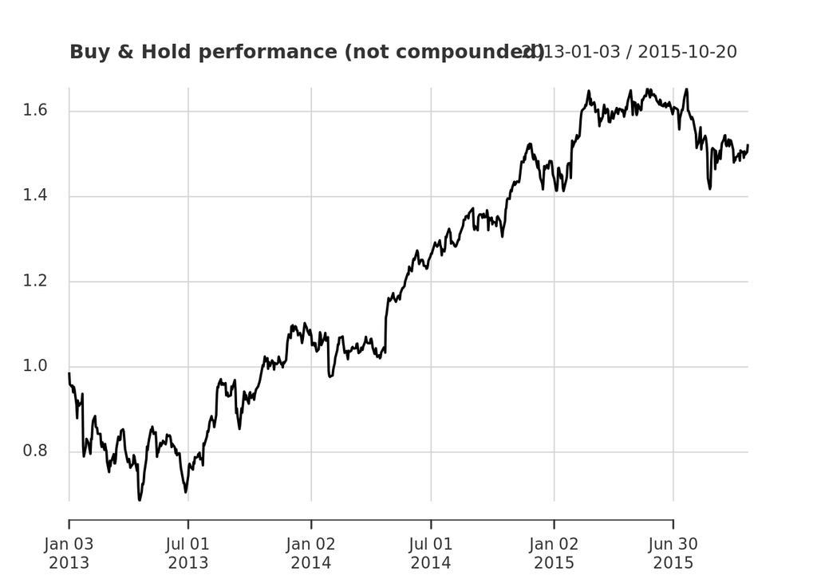

```r
wealth_arith_BnH_trn <- 1 + cumsum(ret_BnH_trn)  # initial budget of 1$
wealth_geom_BnH_trn <- cumprod(1 + ret_BnH_trn)  # initial budget of 1$

# plots
# same as:
#   plot(wealth_arith_BnH_trn[, 1], main = "Buy & Hold performance (not compounded)", ylab = "wealth")
chart.CumReturns(ret_BnH_trn[, 1], main = "Buy & Hold performance (not compounded)",
                 geometric = FALSE, wealth.index = TRUE)
```

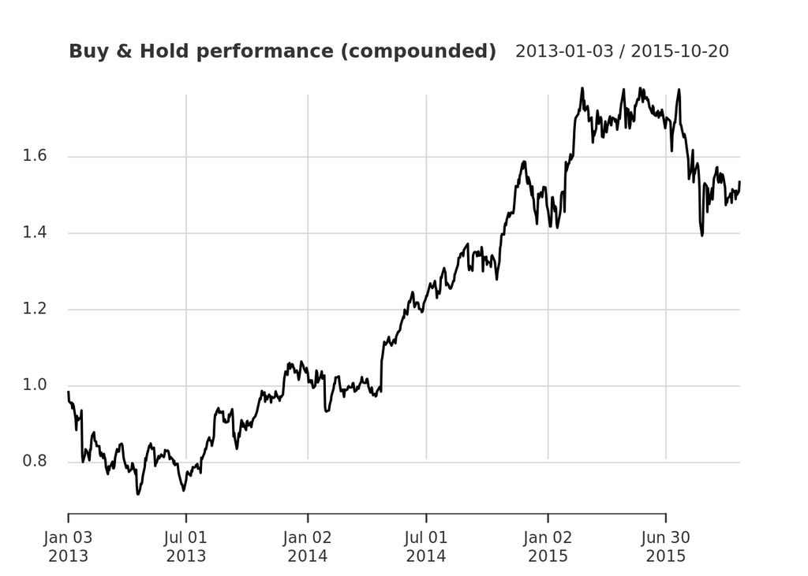

```r
# same as:
#   plot(wealth_geom_BnH_trn[, 1], main = "Buy & Hold performance (compounded)", ylab = "wealth")
chart.CumReturns(ret_BnH_trn[, 1], main = "Buy & Hold performance (compounded)",
                 geometric = TRUE, wealth.index = TRUE)
```

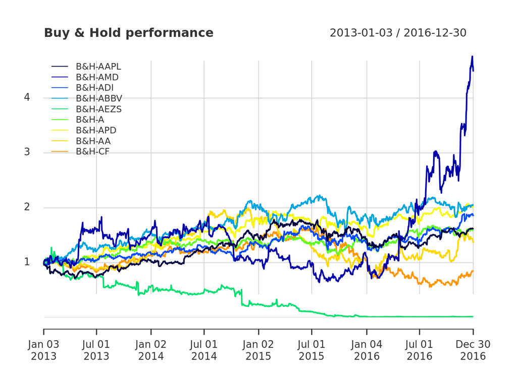

```r
# more plots
chart.CumReturns(ret_BnH, main = "Buy & Hold performance",
                 wealth.index = TRUE, legend.loc = "topleft", colorset = rich10equal)
```

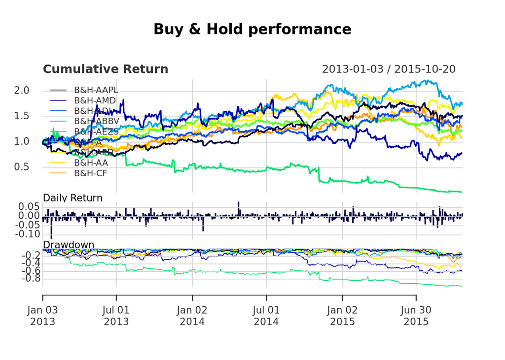

```r
charts.PerformanceSummary(ret_BnH_trn, main = "Buy & Hold performance",
                          wealth.index = TRUE, colorset = rich10equal)
```

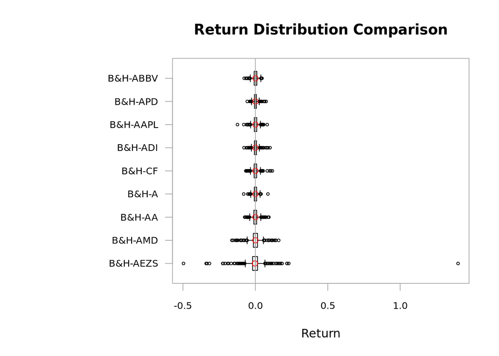

```r
chart.Boxplot(ret_BnH_trn)
```

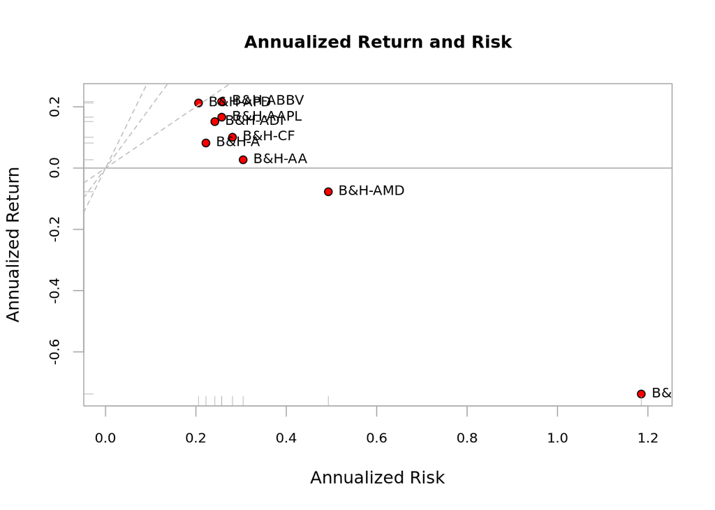

```r
chart.RiskReturnScatter(ret_BnH_trn, symbolset = 21, bg = "red")
```

# Comparison of $\frac{1}{N}$ portfolio, quintile portfolio, and GMRP

The EWP or $\frac{1}{N}$ portfolio allocates equal dollar weight to each stock: **w**$=\frac{1}{N}$**1**.

```r
w_EWP <- rep(1/N, N)
names(w_EWP) <- colnames(X_lin)
w_EWP
```

```
##      AAPL       AMD       ADI      ABBV      AEZS         A       APD        AA
## 0.1111111 0.1111111 0.1111111 0.1111111 0.1111111 0.1111111 0.1111111 0.1111111
##        CF
## 0.1111111
```

**Quintile portfolios** are widely used by practitioners. The idea is to 1) rank the N stocks, 2) divide them into five parts, and 3) long the top part (and possibly short the bottom part). One can rank the stocks in a multitude of ways (typically based on expensive factors that investment funds buy at a premium price). For our experiments, we will consider three possible rankings according to:

1. $\mu$
2. $\frac{\mu}{diag(\Sigma)}$
3. $\frac{\mu}{diag(\sqrt{\Sigma})}$

```r
# find indices of sorted stocks
i1 <- sort(mu, decreasing = TRUE, index.return = TRUE)$ix
i2 <- sort(mu/diag(Sigma), decreasing = TRUE, index.return = TRUE)$ix
i3 <- sort(mu/sqrt(diag(Sigma)), decreasing = TRUE, index.return = TRUE)$ix
mu
```

```
##          AAPL           AMD           ADI          ABBV          AEZS
##  0.0006102079 -0.0003193217  0.0005605781  0.0007783541 -0.0053072766
##             A           APD            AA            CF
##  0.0003123183  0.0007646484  0.0001062232  0.0003806217
```

```r
i1
```

```
## [1] 4 7 1 3 9 6 8 2 5
```

```r
i2
```

```
## [1] 7 4 3 1 6 9 8 2 5
```

```r
i3
```

```
## [1] 7 4 1 3 6 9 8 2 5
```

```r
# create portfolios
w_QuintP_1 <- w_QuintP_2 <- w_QuintP_3 <- rep(0, N)
w_QuintP_1[i1[1:round(N/5)]] <- 1/round(N/5)
w_QuintP_2[i2[1:round(N/5)]] <- 1/round(N/5)
w_QuintP_3[i3[1:round(N/5)]] <- 1/round(N/5)
w_QuintP <- cbind("QuintP (mu)"        = w_QuintP_1,
                  "QuintP (mu/sigma2)" = w_QuintP_2,
                  "QuintP (mu/sigma)"  = w_QuintP_3)
rownames(w_QuintP) <- colnames(X_lin)
w_QuintP
```

```
##      QuintP (mu) QuintP (mu/sigma2) QuintP (mu/sigma)
## AAPL         0.0                0.0               0.0
## AMD          0.0                0.0               0.0
## ADI          0.0                0.0               0.0
## ABBV         0.5                0.5               0.5
## AEZS         0.0                0.0               0.0
## A            0.0                0.0               0.0
## APD          0.5                0.5               0.5
## AA           0.0                0.0               0.0
## CF           0.0                0.0               0.0
```

The **global maximum return portfolio (GMRP)** chooses the stock with the hightest return during the in-sample period:

```r
i_max <- which.max(mu)
w_GMRP <- rep(0, N)
w_GMRP[i_max] <- 1
names(w_GMRP) <- colnames(X_lin)
w_GMRP
```

```
## AAPL  AMD  ADI ABBV AEZS    A  APD   AA   CF
##    0    0    0    1    0    0    0    0    0
```

We can now compare the allocations of the portfolios:

```r
# put together all portfolios
w_heuristic <- cbind("EWP" = w_EWP, w_QuintP, "GMRP" = w_GMRP)
round(w_heuristic, digits = 2)
```

```
##       EWP QuintP (mu) QuintP (mu/sigma2) QuintP (mu/sigma) GMRP
## AAPL 0.11         0.0                0.0               0.0    0
## AMD  0.11         0.0                0.0               0.0    0
## ADI  0.11         0.0                0.0               0.0    0
## ABBV 0.11         0.5                0.5               0.5    1
## AEZS 0.11         0.0                0.0               0.0    0
## A    0.11         0.0                0.0               0.0    0
## APD  0.11         0.5                0.5               0.5    0
## AA   0.11         0.0                0.0               0.0    0
## CF   0.11         0.0                0.0               0.0    0
```

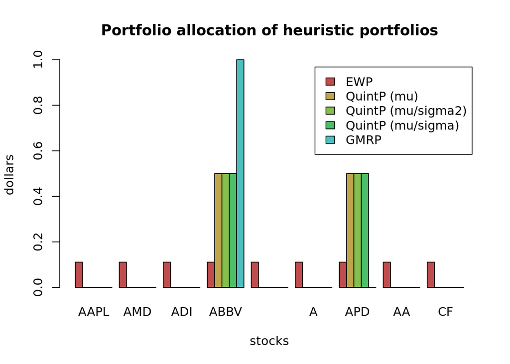

```r
barplot(t(w_heuristic), col = rainbow8equal[1:5],
        legend = colnames(w_heuristic), beside = TRUE,
        main = "Portfolio allocation of heuristic portfolios",
        xlab = "stocks", ylab = "dollars")
```

Then we can compare the performance (in-sample vs out-of-sample):

```r
# compute returns of all portfolios
ret_heuristic <- xts(X_lin %*% w_heuristic, index(X_lin))
ret_heuristic$`QuintP (mu/sigma2)` <- NULL  # remove since it coincides with "QuintP (mu/sigma)"
ret_heuristic_trn <- ret_heuristic[1:T_trn, ]
ret_heuristic_tst <- ret_heuristic[-c(1:T_trn), ]

# performance
t(table.AnnualizedReturns(ret_heuristic_trn))
```

```
##                   Annualized Return Annualized Std Dev
## EWP                          0.0239             0.2054
## QuintP (mu)                  0.2256             0.1899
## QuintP (mu/sigma)            0.2256             0.1899
## GMRP                         0.2167             0.2567
##                   Annualized Sharpe (Rf=0%)
## EWP                                  0.1164
## QuintP (mu)                          1.1877
## QuintP (mu/sigma)                    1.1877
## GMRP                                 0.8442
```

```r
t(table.AnnualizedReturns(ret_heuristic_tst))
```

```
##                   Annualized Return Annualized Std Dev
## EWP                          0.3383             0.2764
## QuintP (mu)                  0.1606             0.1978
## QuintP (mu/sigma)            0.1606             0.1978
## GMRP                         0.1532             0.3080
##                   Annualized Sharpe (Rf=0%)
## EWP                                  1.2238
## QuintP (mu)                          0.8120
## QuintP (mu/sigma)                    0.8120
## GMRP                                 0.4973
```

Let’s plot the wealth evolution (cumulative PnL) over time:

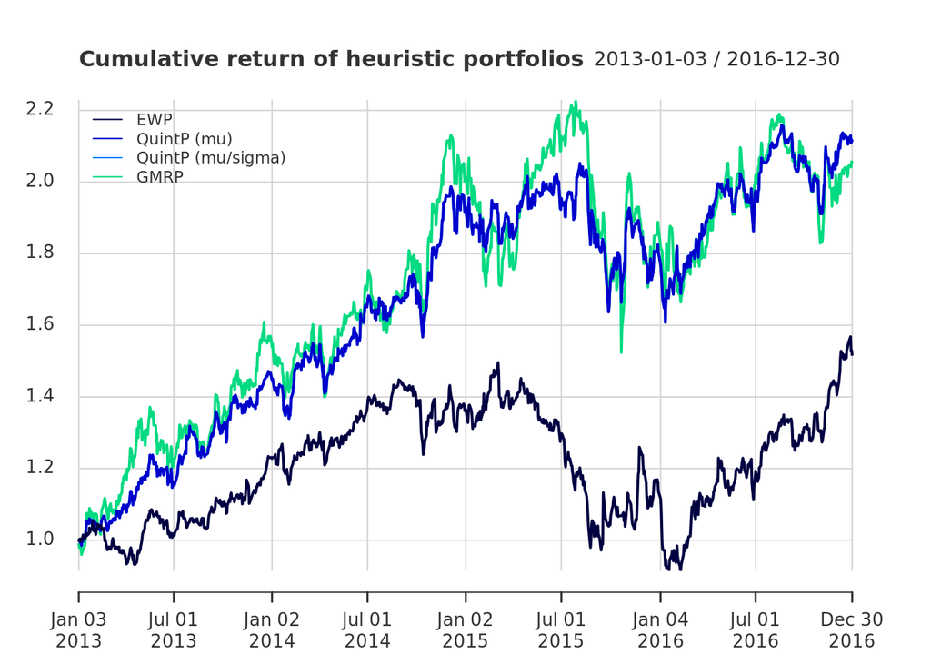

```r
chart.CumReturns(R = ret_heuristic, main = "Cumulative return of heuristic portfolios",
                 wealth.index = TRUE, legend.loc = "topleft", colorset = rich8equal)
```

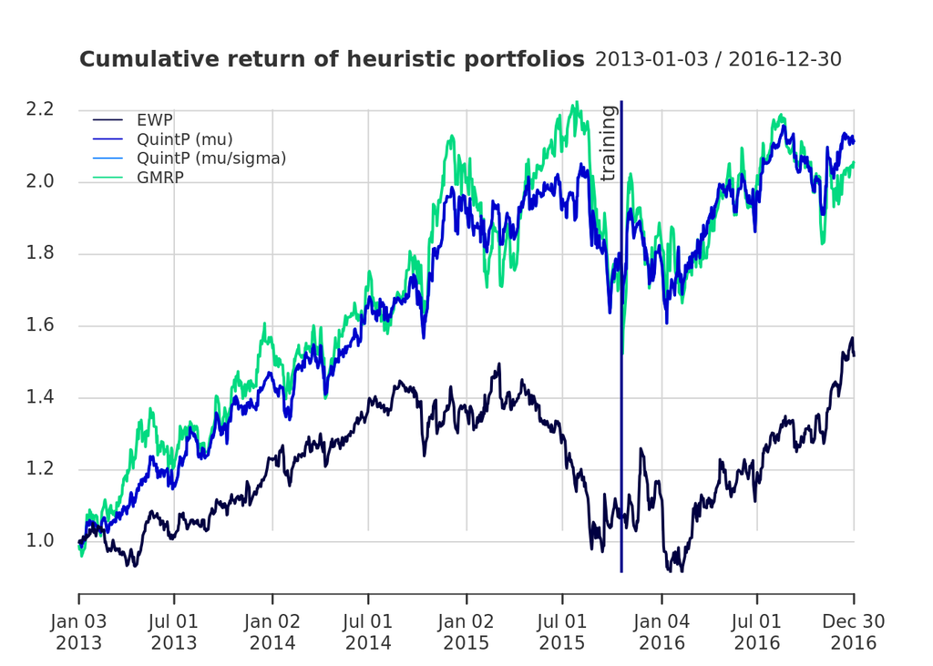

```r
addEventLines(xts("training", index(X_lin[T_trn])), srt = 90, pos = 2,
              lwd = 2, col = "darkblue")
```

Finally, we can plot the risk-return scatter plot:

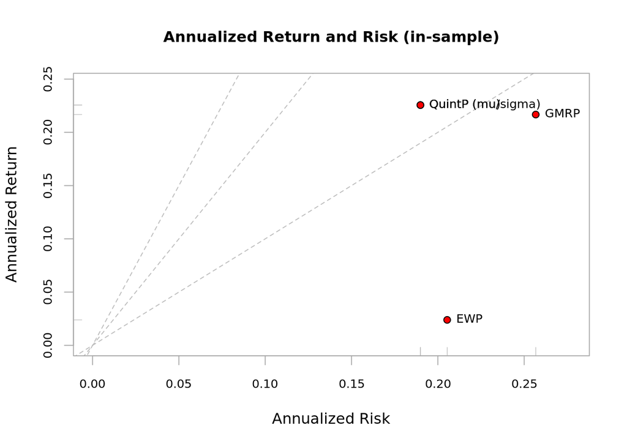

```r
chart.RiskReturnScatter(R = ret_heuristic_trn, symbolset = 21, bg = "red",
                        main = "Annualized Return and Risk (in-sample)")
```

# Markowitz’s mean-variance portfolio (1952)

Markowitz’s mean-variance portfolio (MVP) with no shorting is formulated as:
$$\underset{w}{maximize}\ \ \mu^T w- \lambda w^T \Sigma w \\
\text{subject to } 1^T w = 1 \\
w \ge 0$$
This problem does not have a closed-form solution so we use a solver.

```r
# create function for MVP
MVP <- function(mu, Sigma, lmd = 0.5) {
  w <- Variable(nrow(Sigma))
  prob <- Problem(Maximize(t(mu) %*% w - lmd*quad_form(w, Sigma)),
                  constraints = list(w >= 0, sum(w) == 1))
  result <- solve(prob)
  w <- as.vector(result$getValue(w))
  names(w) <- colnames(Sigma)
  return(w)
}

# this function can now be used as
w_MVP <- MVP(mu, Sigma, lmd = 2)
w_MVP
```

```
##          AAPL           AMD           ADI          ABBV          AEZS
##  1.481632e-01 -7.484248e-23 -3.992344e-23  2.991299e-01  6.610214e-23
##             A           APD            AA            CF
## -3.091048e-24  5.527069e-01 -2.676147e-25  1.204905e-23
```

```r
w_heuristic <- cbind("EWP" = w_EWP, w_QuintP, "GMRP" = w_GMRP, "MVP" = w_MVP)
round(w_heuristic, digits = 2)
```

```
##       EWP QuintP (mu) QuintP (mu/sigma2) QuintP (mu/sigma) GMRP  MVP
## AAPL 0.11         0.0                0.0               0.0    0 0.15
## AMD  0.11         0.0                0.0               0.0    0 0.00
## ADI  0.11         0.0                0.0               0.0    0 0.00
## ABBV 0.11         0.5                0.5               0.5    1 0.30
## AEZS 0.11         0.0                0.0               0.0    0 0.00
## A    0.11         0.0                0.0               0.0    0 0.00
## APD  0.11         0.5                0.5               0.5    0 0.55
## AA   0.11         0.0                0.0               0.0    0 0.00
## CF   0.11         0.0                0.0               0.0    0 0.00
```

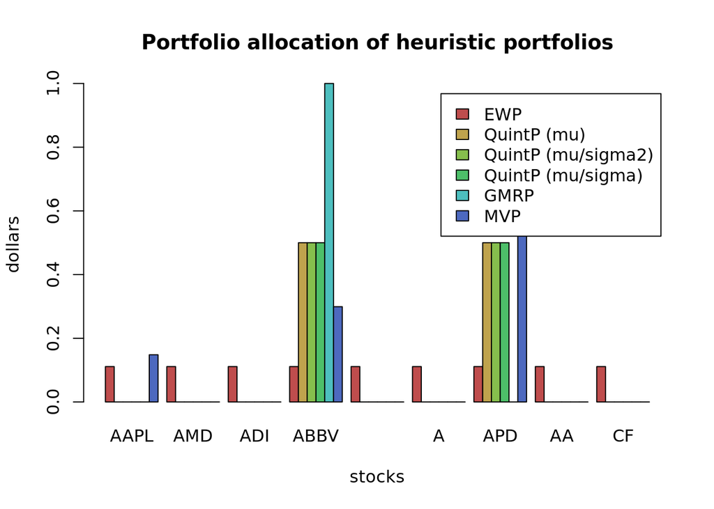

```r
barplot(t(w_heuristic), col = rainbow8equal[1:6],
        legend = colnames(w_heuristic), beside = TRUE,
        main = "Portfolio allocation of heuristic portfolios",
        xlab = "stocks", ylab = "dollars")
```

# Maximum Shapre ratio portfolio (MSRP)

- Markowitz’s mean-variance framework provides portfolios along the Pareto-optimal frontier and the choice depends on the risk-aversion of the investor.
- But typically one measures an investment with the Sharpe ratio: only one portfolio on the Pareto-optimal frontier achieves the maximum Sharpe ratio.
- Precisely, Sharpe (1966) first proposed the maximization of the Sharpe ratio:

$$\underset{w}{maximize}\ \ \frac{w^T \mu - r_f}{\sqrt{w^T \Sigma w}} \\
\text{subject to } 1^T w = 1 \\
w \ge 0$$
where $r_f$ is the return of a risk-free asset.

- The tricky part is that, this problem is not convex. It belongs to the class of **fractional programming (FP)**.

# Maximum Sharpe ratio portfolio via bisection

We are going to solve the non-convex problem
$$\underset{w,t}{maximize}\ \ t\\
\text{subject to } t \le \frac{w^T \mu}{\sqrt{w^T \Sigma w}} \\
1^Tw = 1, (w \ge 0)$$
via bisection on t with the following (convex) SOCP problem for a given t:
$$\text{find } w \\
\text{subject to }\ t\lvert\lvert \Sigma^\frac{1}{2}w\rvert\rvert_2 \le w^T \mu \\
q^T w = 1, (w \ge 0)$$

```r
# define the inner solver based on an SOCP solver
# (we will simply use CVXR for convenience, see: https://cvxr.rbind.io/cvxr_functions/)
library(CVXR)

# square-root of matrix Sigma
Sigma_12 <- chol(Sigma)
max(abs(t(Sigma_12) %*% Sigma_12 - Sigma))  # sanity check
```

```
## [1] 8.673617e-19
```

```r
# create function for MVP
SOCP_bisection <- function(t) {
  w <- Variable(nrow(Sigma))
  prob <- Problem(Maximize(0),
                  constraints = list(t*cvxr_norm(Sigma_12 %*% w, 2) <= t(mu) %*% w,
                                     sum(w) == 1,
                                     w >= 0))
  result <- solve(prob)
  return(list("status" = result$status, "w" = as.vector(result$getValue(w))))
}

# now run the bisection algorithm
t_lb <- 0   # for sure the problem is feasible in this case
t_ub <- 10  # a tighter upper bound could be chosen, but a Sharpe ratio of 10 surely cannot be achieved
while(t_ub - t_lb > 1e-6) {
  t <- (t_ub + t_lb)/2  # midpoint
  if(SOCP_bisection(t)$status == "infeasible")
    t_ub <- t
  else
    t_lb <- t
}
w_bisection <- SOCP_bisection(t_lb)$w

# comparison between two solutions
round(w_bisection, digits = 3)
```

```
## [1] 0.195 0.000 0.015 0.274 0.000 0.000 0.515 0.000 0.000
```

```r
# Sharpe ratio of two solutions
#c("nonlinear_solver" = fn_SR(w_nonlinear_solver),
fn_SR <- function(w) {
  return(as.numeric(t(w) %*% mu / sqrt(t(w) %*% Sigma %*% w)))
}

fn_SR(w_bisection)
```

```
## [1] 0.06916997
```